# Assignment 2.1

Name: Sowrab R Iyengar Date: 15-Sept-2024

For this assignment, you will refer to the textbook to solve the practice exercises. **Use Python to answer any coding problems (not R, even if indicated in your textbook).** Use Jupyter Notebook, Google Colab, or a similar software program to complete your assignment. Submit your answers as a **PDF or HTML** file. As a best practice, always label your axes and provide titles for any graphs generated on this assignment. Round all quantitative answers to 2 decimal places.

## Problem # 2.1.

For the rain simulation example in Section 2.1.1, but with probability of rain 0.30 on any given day, simulate the outcome (a) on the next day, (b) the next 10 days. (c) Simulate the proportion of days of rain for the next (i) 100 days, (ii) 10,000 days, (iii) 1,000,000 days. Use the simulation to explain the long-run relative frequency definition of probability.

`(a) Your answer goes here`

```python
import numpy as np
next_day_rain = np.random.binomial(1, 0.30)
print(next_day_rain)
```

```
1
```

`(b) Your answer goes here`

```python
next_10_days_rain = np.random.binomial(1, 0.30, 10)
print(next_10_days_rain)
```

```
[1 1 0 0 1 1 0 1 0 1]
```

`(c) Your answer goes here`

```python
rain_100_days = np.mean(np.random.binomial(1, 0.30, 100))
rain_10000_days = np.mean(np.random.binomial(1, 0.30, 10000))
rain_1000000_days = np.mean(np.random.binomial(1, 0.30, 1000000))

print(rain_100_days, rain_10000_days, rain_1000000_days)
```

```
0.35 0.2992 0.299483
```

## Problem # 2.2.

Data analysts often implement statistical inference methods by setting the probability of a correct inference equal to 0.95. Let *A* denote the event that an inference for the population about men is correct. Let *B* represent the event of a corresponding inference about women being correct. Suppose that these are independent events.

(a) Find the probability that (i) *both* inferences are correct, (ii) *neither* inference is correct.  
(b) Construct the probability distribution for *Y* = number of correct inferences.  
(c) With what probability would each inference need to be correct in order for the probability to be 0.95 that *both* are correct?

`(a) Your answer goes here`

```python
import math

# Given probability that each inference is correct
p = 0.95

# Probability that both inferences are correct
p_both_correct = p * p
print(p_both_correct)

# Probability that neither inference is correct
p_neither_correct = (1 - p) * (1 - p)
print(p_neither_correct)
```

```
0.9025
0.0025000000000000044
```

`(b) Your answer goes here`

```python
# Probability distribution for Y
p_y_0 = p_neither_correct
p_y_1 = (p * (1 - p)) + ((1 - p) * p)
p_y_2 = p_both_correct

print(f"\n(b) Probability distribution for Y:")
print(f"P(Y = 0): {p_y_0:.4f}")
print(f"P(Y = 1): {p_y_1:.4f}")
print(f"P(Y = 2): {p_y_2:.4f}")
```

```
(b) Probability distribution for Y:
P(Y = 0): 0.0025
P(Y = 1): 0.0950
P(Y = 2): 0.9025
```

`(c) Your answer goes here`

```python
required_p = math.sqrt(0.95)
print(f"\n(c) Required probability for each inference to be correct to achieve P(both correct) = 0.95: {required_p:.4f}")
```

```
(c) Required probability for each inference to be correct to achieve P(both correct) = 0.95: 0.9747
```

## Problem # 2.4.

A wine connoisseur is asked to match five glasses of red wine with the bottles from which they came, representing five different grape types.

(a) Set up a sample space for the five guesses.  
(b) With random guessing, find the probability of getting all five correct.

`(a) Your answer goes here`

Total Number of Permutations: Each of the five glasses can be paired with one of the five grape types, without repetition. This means the number of permutations is calculated as: 5! = 120

`(b) Your answer goes here`

```python
import math

# Number of possible arrangements for 5 items
total_permutations = math.factorial(5)

# Number of favorable outcomes
favorable_outcomes = 1
probability = favorable_outcomes / total_permutations

print(f"The probability of getting all five correct with random guessing is: {probability:}")
```

```
The probability of getting all five correct with random guessing is: 0.008333333333333333
```

## Problem # 2.15.

Each week an insurance company records *Y* = number of payments because of a home burning down. State conditions under which we would expect *Y* to approximately have a Poisson distribution.

`Discrete Events: The Poisson distribution is appropriate for counting the number of discrete payments (in this case, payments). Therefore, the number of payments should be countable.`

## Problem # 2.16.

Each day a hospital records the number of people who come to the emergency room for treatment.

(a) In the first week, the observations from Sunday to Saturday are 10, 8, 14, 7, 21, 44, 60. Do you think that the Poisson distribution might describe the random variability of this phenomenon adequately. Why or why not?  
(b) Would you expect the Poisson distribution to better describe, or more poorly describe, the number of weekly admissions to the hospital for a rare disease? Why?

`(a) Your answer goes here`

`The script calculates the mean and variance of the emergency room visits data. It checks if the mean is close to the variance, which is an indicator of whether the Poisson distribution might be a good fit.`

```python
import numpy as np
import scipy.stats as stats

# Data for emergency room visits
visits = np.array([10, 8, 14, 7, 21, 44, 60])

# Calculate mean and variance
mean_visits = np.mean(visits)
variance_visits = np.var(visits, ddof=1)  # Sample variance

print(f"Mean of visits: {mean_visits:.2f}")
print(f"Variance of visits: {variance_visits:.2f}")

# Poisson distribution check
# Poisson mean should be approximately equal to the variance
if np.isclose(mean_visits, variance_visits, atol=5):
    print("The Poisson distribution might describe the random variability of emergency room visits adequately.")
else:
    print("The Poisson distribution might not describe the random variability of emergency room visits adequately.")
```

```
Mean of visits: 23.43
Variance of visits: 423.95
The Poisson distribution might not describe the random variability of emergency room visits adequately.
```

`(b) Your answer goes here`

`It uses a hypothetical mean for rare disease admissions to demonstrate that if the number of admissions is indeed small and consistent, the Poisson distribution should describe the variability well.`

```python
rare_disease_mean = 3 #Hypothetical
rare_disease_variance = rare_disease_mean  # For Poisson distribution

print(f"Mean of rare disease admissions: {rare_disease_mean}")
print(f"Variance of rare disease admissions: {rare_disease_variance}")

# Conclusion
if np.isclose(rare_disease_mean, rare_disease_variance, atol=1):
    print("The Poisson distribution is likely to describe the number of weekly admissions for a rare disease well.")
else:
    print("The Poisson distribution might not describe the number of weekly admissions for a rare disease adequately.")
```

```
Mean of rare disease admissions: 3
Variance of rare disease admissions: 3
The Poisson distribution is likely to describe the number of weekly admissions for a rare disease well.
```

## Problem # 2.17.

An instructor gives a course grade of B to students who have total score on exams and homeworks between 800 and 900, where the maximum possible is 1000. If the total scores have approximately a normal distribution with mean 830 and standard deviation 50, about what proportion of the students receive a B?

`Your answer goes here`

```python
from scipy.stats import norm

# Parameters of the normal distribution
mean = 830
std_dev = 50

# Boundaries for the grade B
lower_bound = 800
upper_bound = 900

# Calculate the cumulative probability for the boundaries
probability_lower = norm.cdf(lower_bound, mean, std_dev)
probability_upper = norm.cdf(upper_bound, mean, std_dev)

# Proportion of students receiving a B
proportion_b = probability_upper - probability_lower

print(f"Proportion of students receiving a B: {proportion_b:.4f}")
```

```
Proportion of students receiving a B: 0.6450
```

## Problem # 2.20.

Create a data file with the income values in the `Income` data file at the text website.

(a) Construct a histogram or a smooth-curve approximation for the *pdf* of income in the corresponding population by plotting results using the density function in R (explained in Exercise 1.18).  
(b) Of the probability distributions studied in this chapter, which do you think might be most appropriate for these data? Why? Plot the probability function of that distribution having the same mean and standard deviation as the income values. Does it seem to describe the income distribution well?

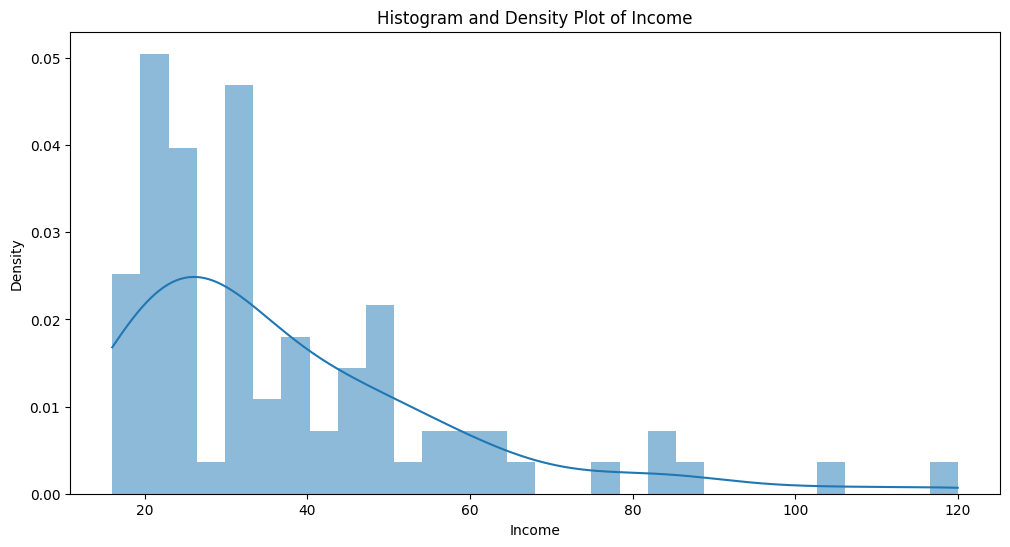

```python
import pandas as pd
import numpy as np
import matplotlib.pyplot as plt
import seaborn as sns

# URL of the data file
url = 'http://stat4ds.rwth-aachen.de/data/Income.dat'

# Load the data into a DF
income_df = pd.read_csv(url, sep="\s+")
income = income_df['income']

# Plot histogram and density function
plt.figure(figsize=(12, 6))
sns.histplot(income, kde=True, stat='density', linewidth=0, bins=30)
plt.title('Histogram and Density Plot of Income')
plt.xlabel('Income')
plt.ylabel('Density')
plt.show()
```

`(a) Your answer goes here`

`(b) Your answer goes here`

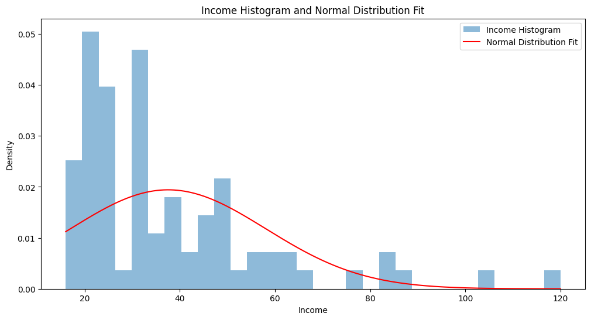

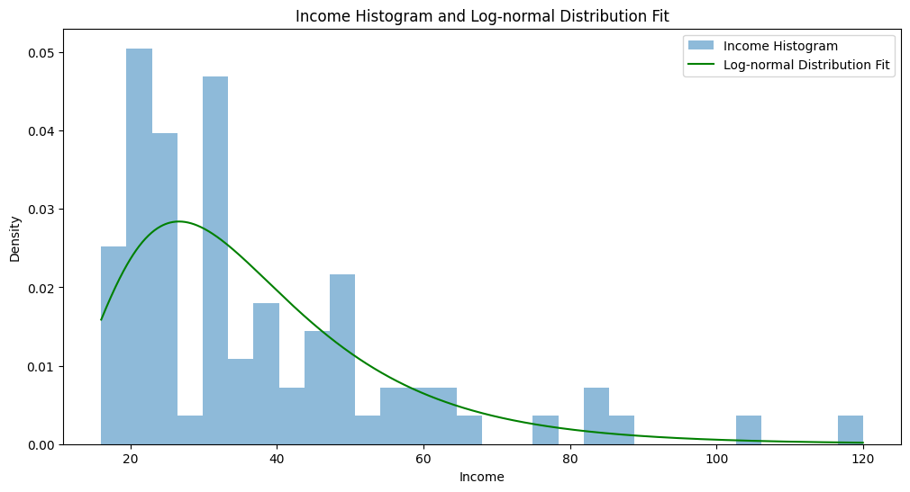

```python
from scipy.stats import norm, lognorm

mean_income = np.mean(income)
std_income = np.std(income)

# Plot normal distribution
x = np.linspace(income.min(), income.max(), 1000)
normal_pdf = norm.pdf(x, mean_income, std_income)

plt.figure(figsize=(12, 6))
plt.hist(income, bins=30, density=True, alpha=0.5, label='Income Histogram')
plt.plot(x, normal_pdf, 'r-', label='Normal Distribution Fit')
plt.title('Income Histogram and Normal Distribution Fit')
plt.xlabel('Income')
plt.ylabel('Density')
plt.legend()
plt.show()

# Fit and plot log-normal distribution
shape, loc, scale = lognorm.fit(income, floc=0)
lognorm_pdf = lognorm.pdf(x, shape, loc=loc, scale=scale)

plt.figure(figsize=(12, 6))
plt.hist(income, bins=30, density=True, alpha=0.5, label='Income Histogram')
plt.plot(x, lognorm_pdf, 'g-', label='Log-normal Distribution Fit')
plt.title('Income Histogram and Log-normal Distribution Fit')
plt.xlabel('Income')
plt.ylabel('Density')
plt.legend()
plt.show()
```

## Problem # 2.21.

Plot the gamma distribution by fixing the shape parameter *k* = 3 and setting the scale parameter = 0.5, 1, 2, 3, 4, 5. What is the effect of increasing the scale parameter? (See also Exercise 2.48.)

`Your answer goes here`

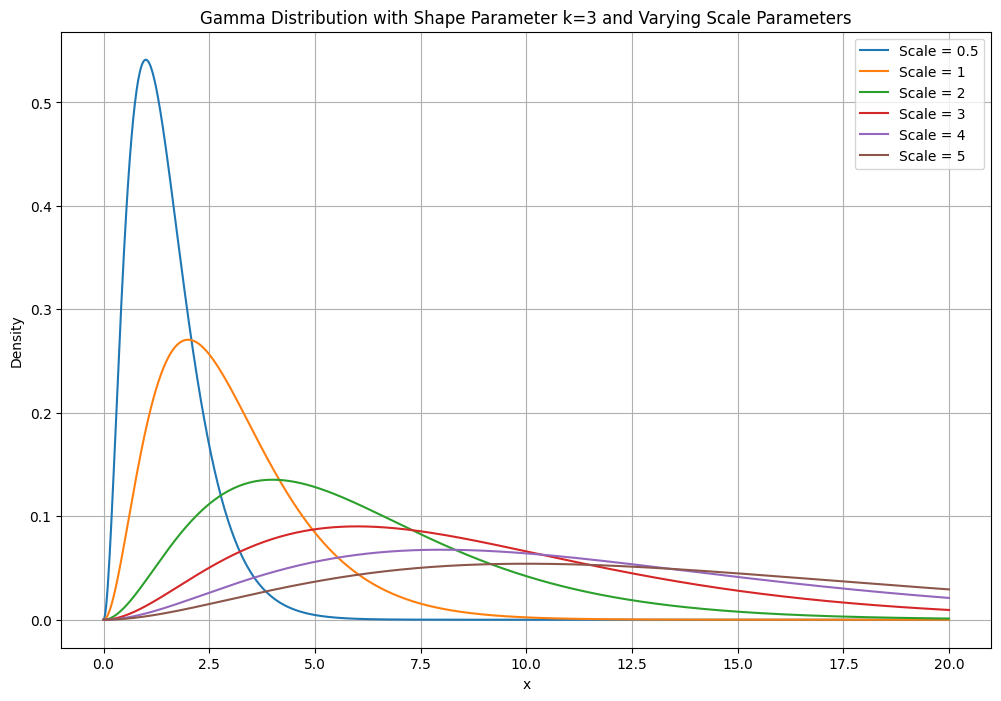

```python
import numpy as np
import matplotlib.pyplot as plt
from scipy.stats import gamma

# Fixed shape parameter k
k = 3

# Scale parameters to vary
scale_params = [0.5, 1, 2, 3, 4, 5]

# Generate x values for plotting
x = np.linspace(0, 20, 1000)

# Plot Gamma distributions with different scale parameters
plt.figure(figsize=(12, 8))

for scale in scale_params:
    y = gamma.pdf(x, a=k, scale=scale)
    plt.plot(x, y, label=f'Scale = {scale}')

# Add plot labels and legend
plt.title('Gamma Distribution with Shape Parameter k=3 and Varying Scale Parameters')
plt.xlabel('x')
plt.ylabel('Density')
plt.legend()
plt.grid(True)
plt.show()
```

## Problem # 2.22.

Consider the mammogram diagnostic example in Section 2.1.4.

(a) Show that the joint probability distribution of diagnosis and disease status is as shown in Table 2.6. Given that a diagnostic test result is positive, explain how this joint distribution shows that the 12% of incorrect diagnoses for the 99% of women not having breast cancer swamp the 86% of correct diagnoses for the 1% of women actually having breast cancer.  
(b) The first test for detecting HIV-positive status had a sensitivity of 0.999 and specificity of 0.9999. Explain what these mean. If at that time 1 in 10,000 men were truly HIVpositive, find the positive predictive value. Based on this example, explain the potential disadvantage of routine diagnostic screening of a population for a rare disease.

**TABLE 2.6** Joint probability distribution for disease status and diagnosis of breast cancer mammogram, based on conditional probabilities in Table 2.1

| **Disease Status** | **Diagnosis from Mammogram** |  |  |
| --- | --- | --- | --- |
|  | Positive (+) | Negative (-) | **Total** |
| Yes (D) | 0.0086 | 0.0014 | 0.01 |
| No ($D^c$) | 0.1188 | 0.8712 | 0.99 |

## Problem # 2.27.

The distribution of *X* = heights *(cm)* of women in the U.K. is approximately *N*(162, $7^2$). Conditional on *X = x*, suppose *Y* = weight *(kg)* has a *N*(3.0 + 0.40x, $8^2$) distribution. Simulate and plot 1000 observations from this approximate bivariate normal distribution. Approximate the marginal means and standard deviations for *X* and *Y*. Approximate and interpret the correlation.

`Your answer goes here`

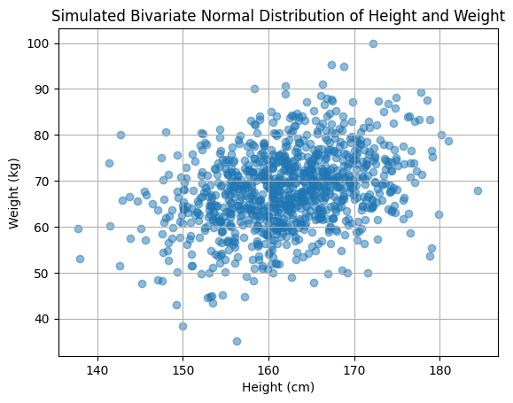

```
(np.float64(162.09371585123793),
 np.float64(7.159539076700376),
 np.float64(67.99869034016122),
 np.float64(8.514037241544614),
 np.float64(0.3338635011770339))
```

```python
import numpy as np
import matplotlib.pyplot as plt

# Given parameters for X ~ N(162, 7^2)
mu_x = 162  # mean of X
sigma_x = 7  # standard deviation of X

# Given parameters for Y | X ~ N(3.0 + 0.40*X, 8^2)
mu_y_given_x_intercept = 3.0
mu_y_given_x_slope = 0.40
sigma_y_given_x = 8  # standard deviation of Y given X

# Number of observations to simulate
n = 1000

# Simulate X from N(162, 7^2)
X = np.random.normal(mu_x, sigma_x, n)

# Simulate Y conditional on X from N(3.0 + 0.40*X, 8^2)
Y = np.random.normal(mu_y_given_x_intercept + mu_y_given_x_slope * X, sigma_y_given_x)

# Plotting the simulated data
plt.scatter(X, Y, alpha=0.5)
plt.title('Simulated Bivariate Normal Distribution of Height and Weight')
plt.xlabel('Height (cm)')
plt.ylabel('Weight (kg)')
plt.grid(True)
plt.show()

# Approximating marginal means and standard deviations
mean_x = np.mean(X)
std_x = np.std(X)
mean_y = np.mean(Y)
std_y = np.std(Y)

# Calculate the correlation between X and Y
correlation = np.corrcoef(X, Y)[0, 1]

mean_x, std_x, mean_y, std_y, correlation
```

`From the simulation of 1000 observations of heights (X) and weights (Y):

The marginal mean of X (heights) is approximately 162.093 cm, with a standard deviation of 7.15 cm. The marginal mean of Y (weights) is approximately 67.99 kg, with a standard deviation of 8.51 kg. The correlation between X and Y is approximately 0.33.`